# EDA

Edgar Bahilo

13/12/2020

## Investigations of sentiment data set using tidytext

Before proceeding to a brute-force modeling approach it is decided to perform a basic text analysis of the dataset. This is mainly because it has been 2 years since the last time that the author worked with NLP and text data. Also the author considers that an understanding of the data set might help him in diagnosing why the model is performing correctly or not and can give additional hindsights helping in the cleaning and feature engineering .

```r
library(vroom)
library(logger)
library(optparse)
library(dplyr)
library(tidyr)
library(tidytext)
library(textdata)
library(stringr)
library(stopwords)
library(tidymodels)
library(textrecipes)
library(discrim)
library(tune)
library(dials)
library(vip)
library(yardstick)

source("../code/get_data.R")
source("../code/process_data.R")
source("../code/plotting_utils.R")
source("../code/train.R")
```

First we investigate the class balance in the original dataset:

```r
twitter_data_big <- loadData(input_path = "../data/input/",
                                    file_name = "twitter_dataset_full.csv") %>%
  select(is_positive, message)
```

```
## INFO [2020-12-14 09:01:56] Reading data succeded
```

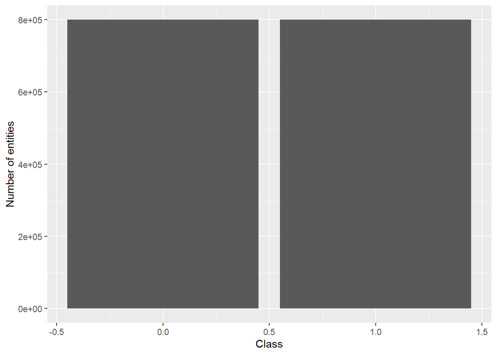

```r
ggplot(twitter_data_big, aes(is_positive))+geom_bar() + xlab("Class") + ylab("Number of entities")
```

The data set seems perfectly balanced so we do not need to worry about class imbalance.

## Basic sentiment analysis

After the dataset is loaded we proceed to execute the preprocessing pipeline. It is important to mention that there are two steps in this pipeline.

1. The cleaning of the message column which basically includes: removing retweets, special characters (@, #, <,>), removing urls (http and https) and forcing the lower case of the messages.
2. The feature engineering and feature augmentation where we tokenize the text, remove stopwords, calculate ngrams, calculate tf-idf and we limit the number of tokens (which potentially can be considered as an hyperparameter).

We select a random sample of the original dataset (due to computation resources limitations) with maximum 50000 datapoints.

```r
processed_data <- processorBasic(df = twitter_data_big,
                                 sample_size = 50000)
```

```
## INFO [2020-12-14 09:02:01] Selecting 50000 observations
## INFO [2020-12-14 09:02:01] Removed retweets
## INFO [2020-12-14 09:02:01] Removed @usernames and hashtags
## INFO [2020-12-14 09:02:01] Changing & by and
## INFO [2020-12-14 09:02:01] Cleaning spaces
## INFO [2020-12-14 09:02:02] Removed < and >
## INFO [2020-12-14 09:02:02] URLs removed
## INFO [2020-12-14 09:02:02] Forced lowercase
## INFO [2020-12-14 09:02:02] Processing Data Succeded
```

We get the top words of the sample dataset, this time we remove the stop words here as well to get meaningful results.

```r
get_top_words(processed_data, 6)
```

```
## INFO [2020-12-14 09:02:04] Plot succeded
```

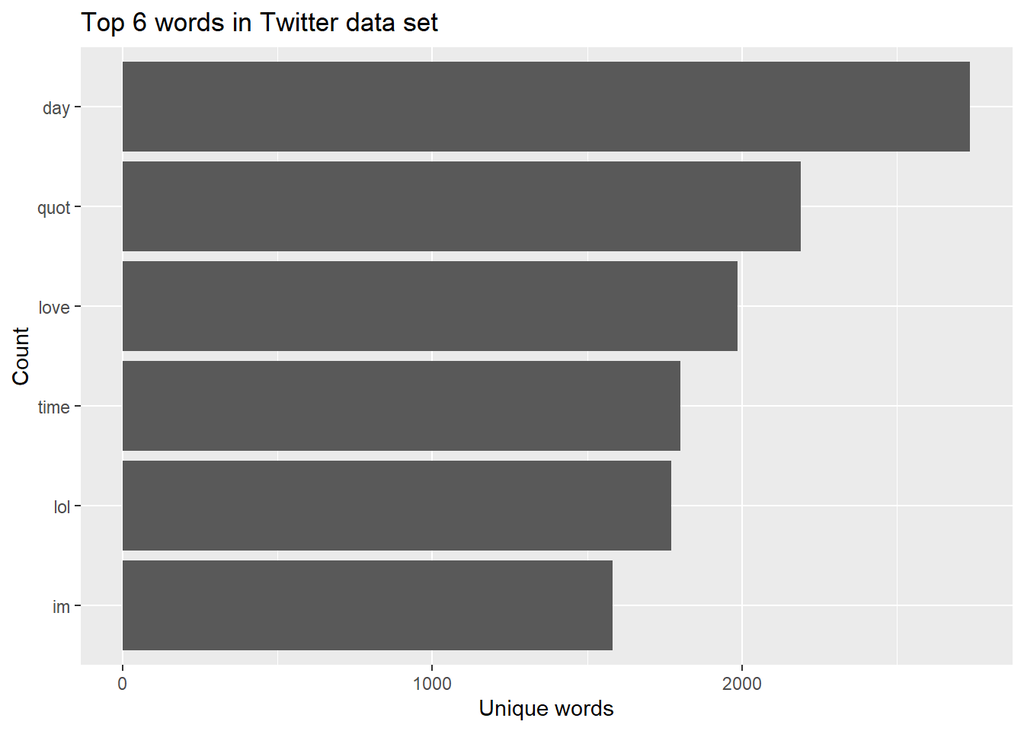

We also perform a very vanilla sentiment analisys:

```r
sentiment_results <- sentimentAnalyser(cleaned_df = processed_data,
                                       engine = "bing")
```

```
## INFO [2020-12-14 09:02:05] Sentiment table generated using engine: bing
## INFO [2020-12-14 09:02:05] Sentiment Analyser Succeded
```

```
## INFO [2020-12-14 09:02:05] Plot succeded
```

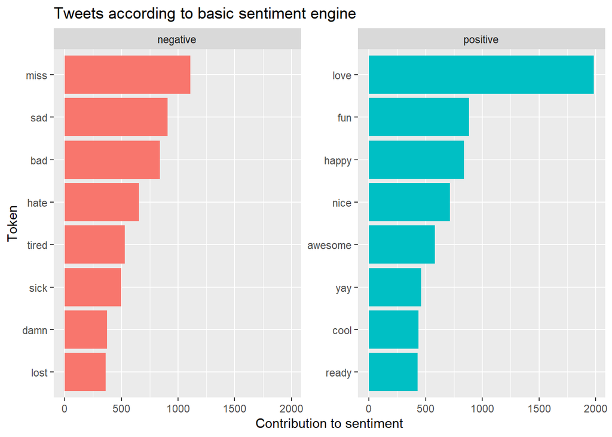

```r
get_sentiments_plot(sentiment_results,number_top = 8)
```

We can see how a simple sentiment engine is actually getting some words in the rigth box (omitting of course any kind of context or additional text corpus information) but this could be an indicator that an ML or DL algorithm will be able to produce some results.

## Training Pipeline - XGBoost

As described before we execute the second part of the preprocessing pipeline, the steps can be found in code/train.R @trainRecipe(), we also generate a grid to tune xgboost, and we also generate an stratification sampling:

```r
training_configuration <- trainRecipe(processed_data,
            max_tokens = 400)
```

```
## INFO [2020-12-14 09:02:05] Initial split done
## INFO [2020-12-14 09:02:05] Training split done
## INFO [2020-12-14 09:02:05] Testing split done
## INFO [2020-12-14 09:02:05] Training recipe succeded
```

```r
xgb_model <- modelDef(mode = "classification",
                      engine = "xgboost")
xgb_grid <- xgbGrid(training_data = training_configuration[[2]])

folds <- vfold_cv(training_configuration[[2]],
                  v = 3,
                  strata = "is_positive",
                  repeats = 1)

load_model <- readRDS(file = "../model/xgboost+recipes.rds")
```

We execute the training process (not show here because if not the notebook render takes ages) and we save the model in the model folder. Below it is displayed the results of the HPO:

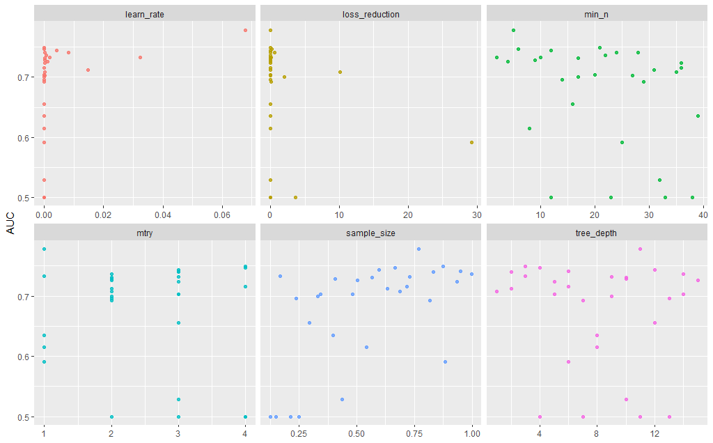

We also plot the ROC curve for the best model:

[figure not shown]

## Inference Pipeline

Now with the trained model in the subset of the large data set we try to predict in the one attached in the modulai github repo.

```r
twitter_data_small %>% head()
```

```
## # A tibble: 6 x 8
##   is_positive     id datetime user  text_stripped bart_is_positive xgboost_pred
##   <fct>        <dbl> <chr>    <chr> <chr>                    <dbl>        <dbl>
## 1 0           2.32e9 Thu Jun~ gulti had dream sn~          0.0752             2
## 2 1           2.19e9 Tue Jun~ lpgr~ richmondgl m~          0.00355            2
## 3 0           1.82e9 Sat May~ star~ sherrymain t~          0.858              2
## 4 0           2.25e9 Fri Jun~ baby~ angelic rebe~          0.226              1
## 5 1           2.05e9 Fri Jun~ Gelf~ middleclassg~          0.499              1
## 6 1           1.97e9 Sat May~ craz~ shomygosh su~          0.991              2
## # ... with 1 more variable: binary_bart <dbl>
```

We then compute the ROC metrics in this new dataset for the two models

```r
roc_auc(twitter_data_small, truth = is_positive, binary_bart)
```

```
## # A tibble: 1 x 3
##   .metric .estimator .estimate
##   <chr>   <chr>          <dbl>
## 1 roc_auc binary         0.295
```

```r
roc_auc(twitter_data_small, truth = is_positive, xgboost_pred)
```

```
## # A tibble: 1 x 3
##   .metric .estimator .estimate
##   <chr>   <chr>          <dbl>
## 1 roc_auc binary         0.292
```